# Exponential Distribution and Central Limit Theorem

Jenhau Chen

February 15, 2016

# Overview

This is a simulation to demonstrate Central Limit Theorem by using Exponential Distribution, which has the following properties:

- **PDF** $\lambda e^{-\lambda x}$
- **CDF** $1 - e^{-\lambda x}$
- **Mean** $\lambda^{-1}$
- **Variance** $\lambda^{-2}$

# Simulations

```r
# simulation parameters
# number of observations
n = 40
# number of simulations
sim_n = 1000
# rate
lambda = 0.2

# Theoretical mean
mu = lambda^(-1)

# Theoretical variance
sigma_sq = lambda^(-2)

# Theoretical standard deviation
sigma = lambda^(-1)

# Standard Error
se = lambda^(-1)/sqrt(n)

# set the seed so our random generation is reproducible
set.seed(40)

mean_distribution = NULL
var_distribution = NULL
sd_distribution = NULL
clt_distribution = NULL
```

[figure not shown]

```r
for(i in 1: sim_n) {
  mean_distribution = c(mean_distribution, mean(rexp(n, lambda)))
}

mean_df = data.frame(x = mean_distribution)

for(i in 1: sim_n) {
  var_distribution = c(var_distribution, var(rexp(n, lambda)))
}

var_df = data.frame(x = var_distribution)

for(i in 1: sim_n) {
  sd_distribution = c(sd_distribution, sd(rexp(n, lambda)))
}

sd_df = data.frame(x = sd_distribution)
```

# Sample Mean vs Theoretical Mean

When comparing with the theoretical mean, $\lambda^{-1}=1/0.2=5$, the following plot shows the sample mean converging to the theoretical mean:

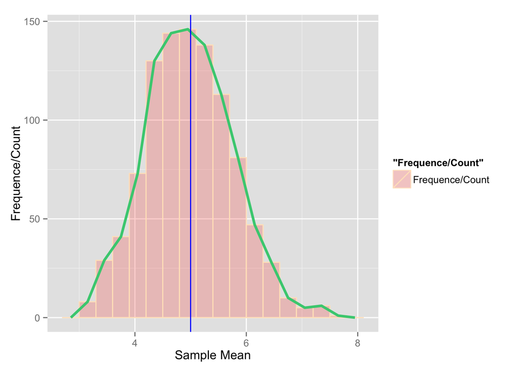

# Sample Variance vs Theoretical Variance

Similiarly when comparing with the theoretical variance, $\lambda^{-2}=(1/0.2)^{2}=25$, the following plot shows the sample variance converging to the theoretical variance:

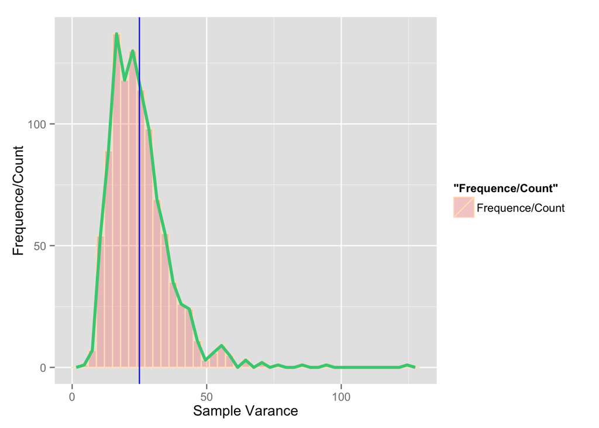

However notice the long tail on the right. I believe it is due to how variance is calculated. If I use standard deviation instead, the plot becomes more Gaussian:

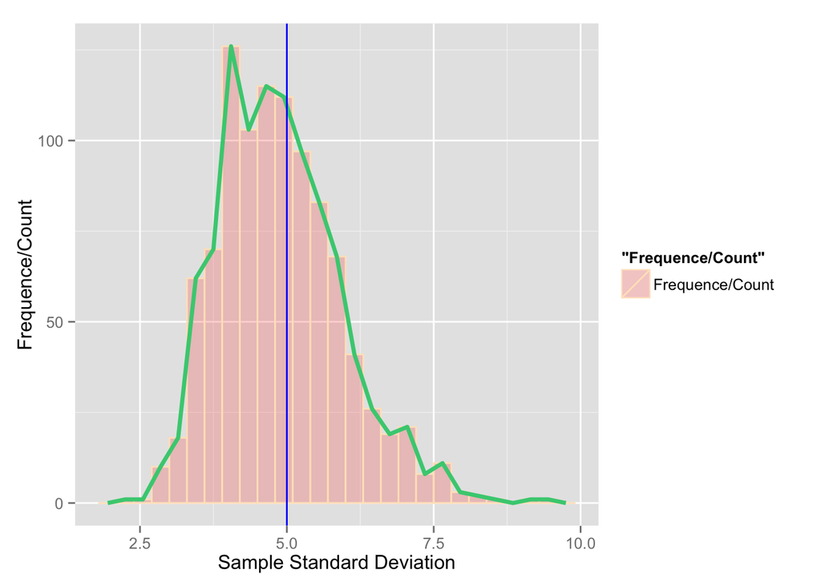

# Distribution

## Sample Mean vs. Normal Density

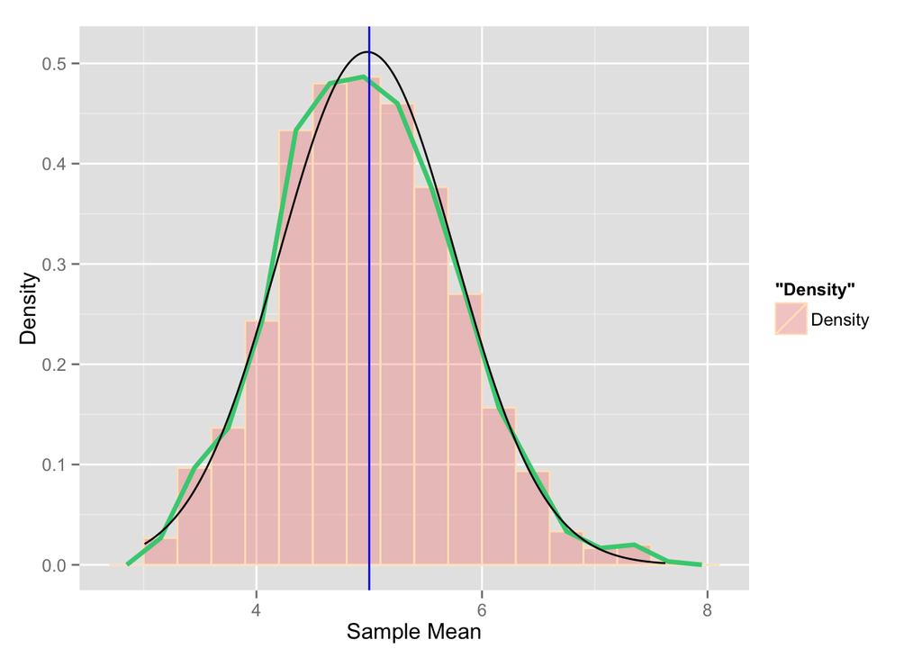

## Sample Variance vs. Normal Density

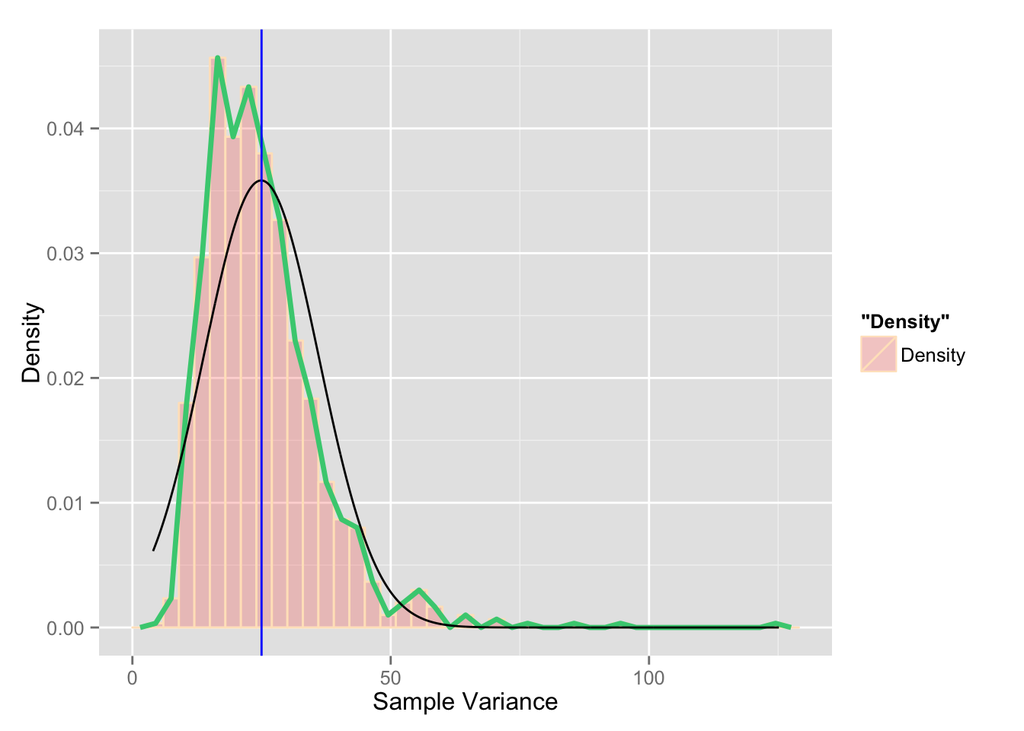

## Sample Standard Deviation vs. Normal Density

Again I don’t like seeing the long tail so I am using standard deviation distribution to validate CLT:

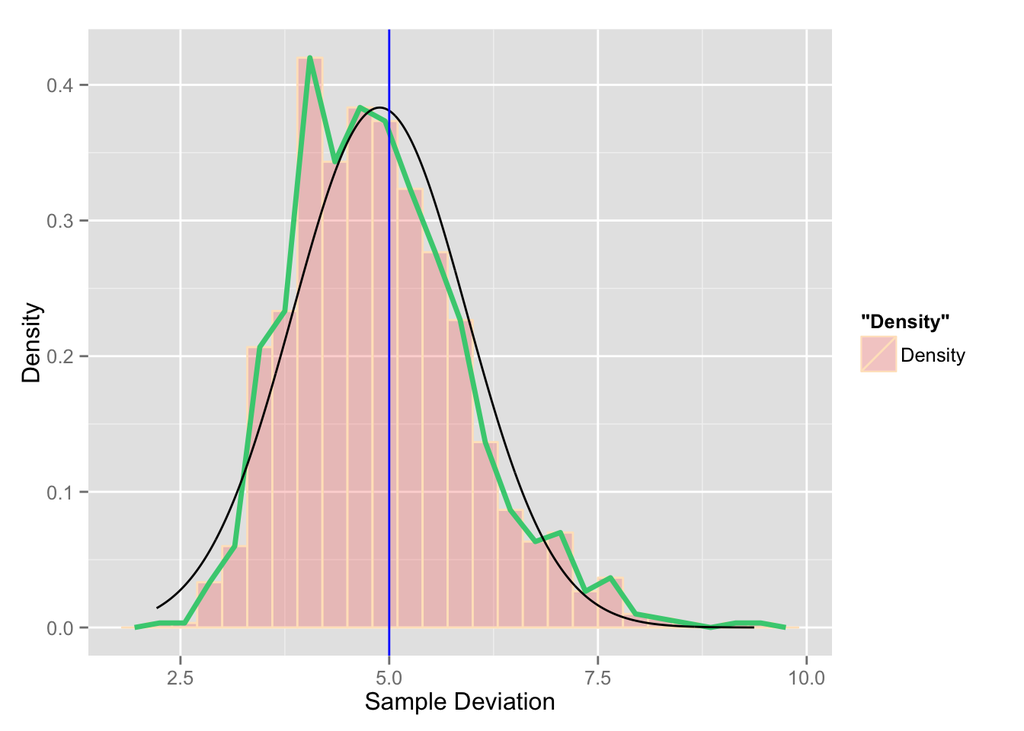

## Normalized Distribution

Lastly according to CLT, I am expecting  
$\frac{\bar X_n - \mu}{\sigma / \sqrt{n}}= \frac{\sqrt n (\bar X_n - \mu)}{\sigma} = \frac{\mbox{Estimate} - \mbox{Mean of estimate}}{\mbox{Std. Err. of estimate}}$ has a distribution like that of a standard normal for large $n$.

Playing with the similuation data again, I have the following plot which validates this point:

```r
for(i in 1: sim_n) {
  clt_distribution = c(clt_distribution, (mean_distribution[i] - mu)/se)
}
clt_df = data.frame(x = clt_distribution)
```

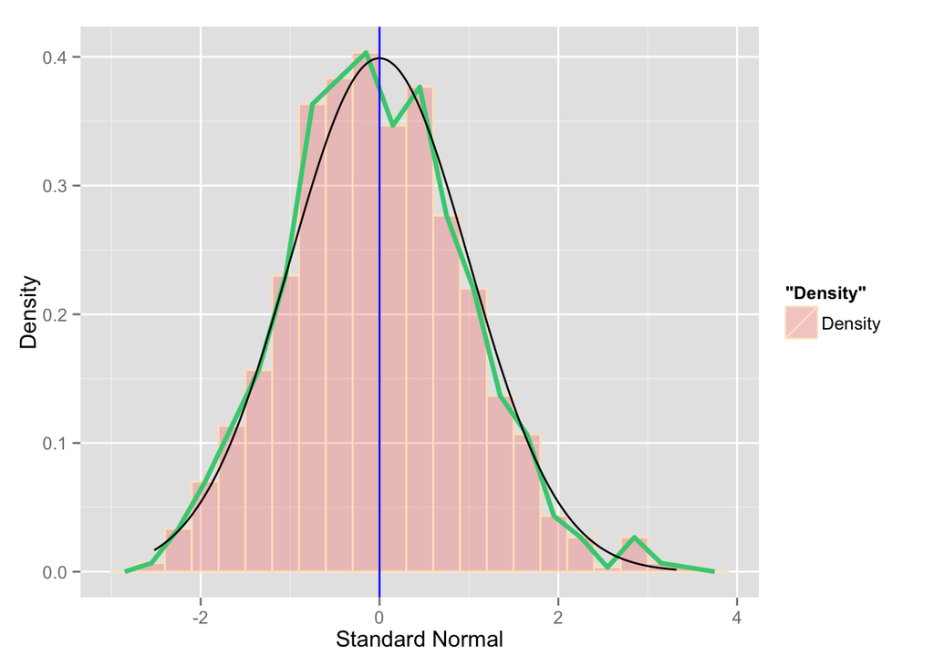